# Project 2: Data Mining, Classification, Prediction

SDS322E

# Mining, Classification, Prediction

## Joshua Nahm (jkn557)

### Introduction

The dataset that was selected contains exam and course grade data from a statistics class. This data was retrieved from the Github source from the vincentarelbundock website. Within this dataset, there are a total of 7 variables: `number`, `semester`, `sex`, `exam1`, `exam2`, `exam3`, and `course_grade`. The variables that will be specifically investigated are `sex`, `exam1`, `exam2`, `exam3`, and `course_grade` with `sex` serving as the binary variable. The `exam1`, `exam2`, and `exam3` variables are numeric variables that indicate the scores of the respective exams for each student during the semester. On the other hand, the `course_grade` variable represents the final grade of the student. In total, there are 232 observations, and there are 187 observations for the Man group and 45 observations for the Woman group.

```r
library(tidyverse)
# read your datasets in here, e.g., with read_csv()
grades <- read_csv("exam_grades.csv")
grades <- grades %>% select(1, 3:7) %>% na.omit
# if your dataset needs tidying, do so here

# any other code here
glimpse(grades)
```

```
## Rows: 232
## Columns: 6
## $ studentid    <dbl> 1, 2, 3, 4, 5, 6, 7, 8, 9, 10, 11, 12, 13, 14, 15, 16, 1…
## $ sex          <chr> "Man", "Man", "Man", "Man", "Man", "Man", "Man", "Man", …
## $ exam1        <dbl> 84.5, 80.0, 56.0, 64.0, 90.5, 74.0, 60.5, 89.0, 87.5, 91…
## $ exam2        <dbl> 69.5, 74.0, 70.0, 61.0, 72.5, 78.5, 44.0, 82.0, 86.5, 98…
## $ exam3        <dbl> 86.5, 67.0, 71.5, 67.5, 75.0, 84.5, 58.0, 88.0, 95.0, 88…
## $ course_grade <dbl> 76.2564, 75.3882, 67.0564, 63.4538, 72.3949, 71.4128, 56…
```

```r
grades %>% group_by(sex) %>% count()
```

```
## # A tibble: 2 x 2
## # Groups:   sex [2]
##   sex       n
##   <chr> <int>
## 1 Man     187
## 2 Woman    45
```

### Cluster Analysis

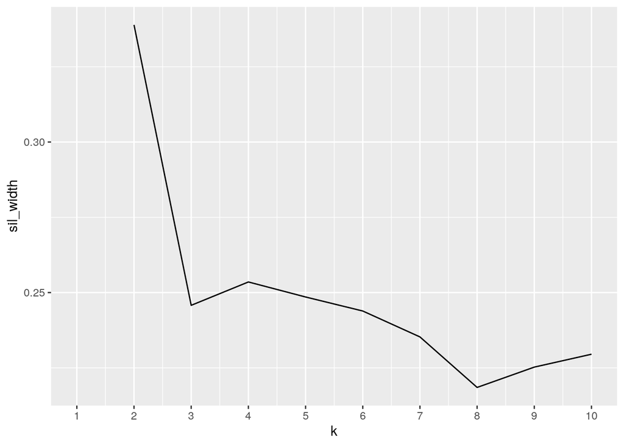

```r
library(cluster)
library(GGally)
# clustering code here
dat1 <- grades %>% select(exam1, exam2, exam3, course_grade)
sil_width <- vector()
for (i in 2:10) {
    pam_fit <- pam(dat1, k = i)
    sil_width[i] <- pam_fit$silinfo$avg.width
}
ggplot() + geom_line(aes(x = 1:10, y = sil_width)) + scale_x_continuous(name = "k",
    breaks = 1:10)
```

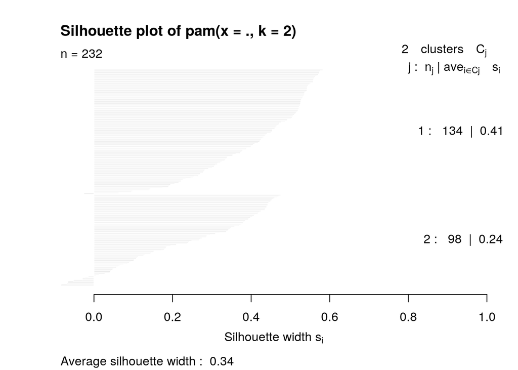

```r
grades_pam <- dat1 %>% pam(k = 2)
plot(grades_pam, which = 2)
```

```r
grades_pam$silinfo$avg.width
```

```
## [1] 0.3389009
```

```r
grades %>% slice(grades_pam$id.med)
```

```
## # A tibble: 2 x 6
##   studentid sex   exam1 exam2 exam3 course_grade
##       <dbl> <chr> <dbl> <dbl> <dbl>        <dbl>
## 1       207 Man    85.7  77.1  83.3         79.9
## 2       134 Man    80.3  63    64           64.7
```

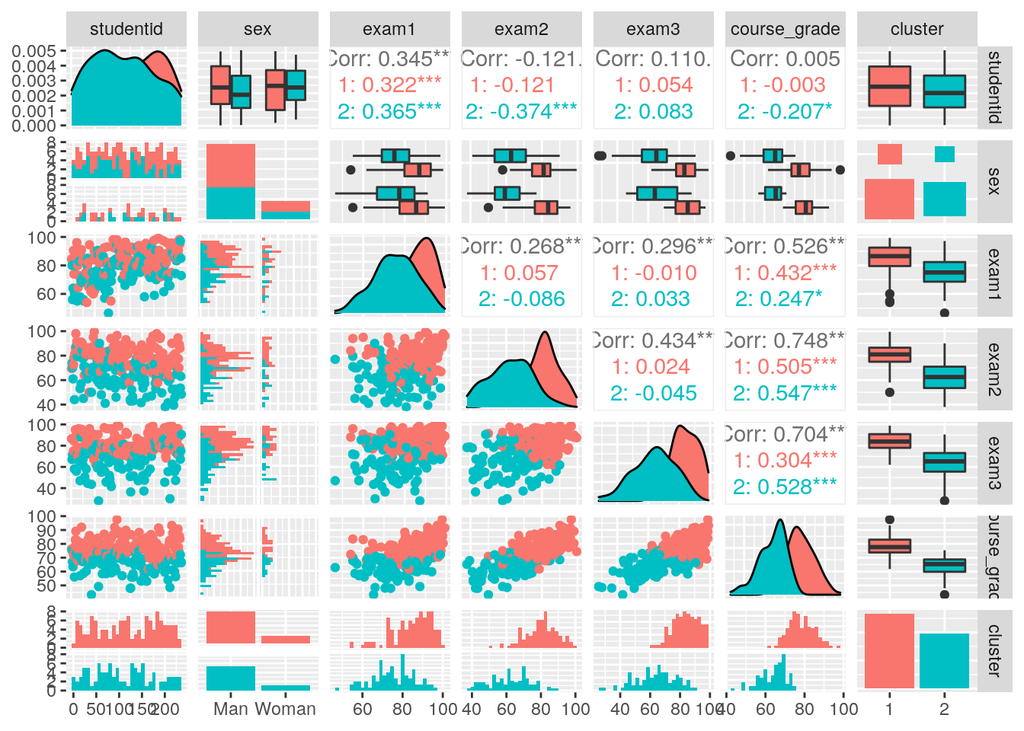

```r
grades_clus <- grades %>% mutate(cluster = factor(grades_pam$clustering))
ggpairs(grades_clus, cols = 2:5, aes(color = cluster))
```

Initially, after using the ggplot function, it was determined that the number of clusters in this dataset was 2. In terms of overall average silhouette width, the average silhouette width was found to be approximately 0.34, which is considered to be a weak structure and could be considered artificial as it falls within the range of 0.26 and 0.50. Between the two clusters, the first cluster is wider than the second. The `sex` Man serves as both medoids. They are most similar on `exam1` and most different on `exam3`.

Based on the function ggpairs, `exam3` appears to show the greatest difference between clusters, and `exam1` appears to show the least difference between clusters. Cluster 2, or the blue cluster, appears to have lesser `exam1`, lesser `exam2`, lesser `exam3`, and lesser `course_grade`.

### Dimensionality Reduction with PCA

```r
# PCA code here
grades_select <- grades %>% select(3:6)
pca1 <- princomp(grades_select, cor = T)
summary(pca1, loadings = T)
```

```
## Importance of components:
##                          Comp.1    Comp.2    Comp.3     Comp.4
## Standard deviation     1.592506 0.8770368 0.7522617 0.35893302
## Proportion of Variance 0.634019 0.1922984 0.1414744 0.03220823
## Cumulative Proportion  0.634019 0.8263174 0.9677918 1.00000000
##
## Loadings:
##              Comp.1 Comp.2 Comp.3 Comp.4
## exam1         0.387  0.891         0.228
## exam2         0.499 -0.379  0.643  0.441
## exam3         0.491 -0.243 -0.762  0.346
## course_grade  0.600               -0.796
```

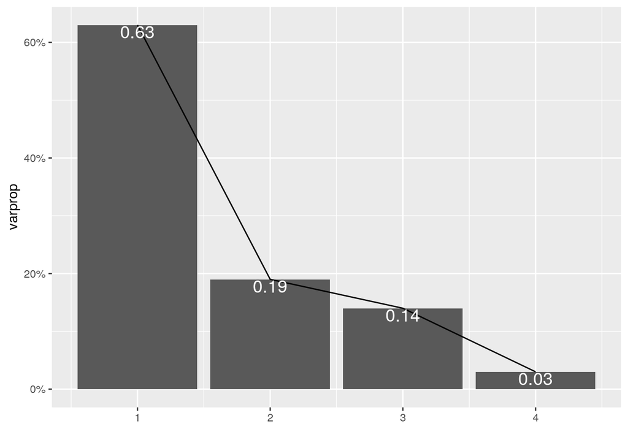

```r
eigval <- pca1$sdev^2
varprop = round(eigval/sum(eigval), 2)

ggplot() + geom_bar(aes(y = varprop, x = 1:4), stat = "identity") +
    xlab("") + geom_path(aes(y = varprop, x = 1:4)) + geom_text(aes(x = 1:4,
    y = varprop, label = round(varprop, 2)), vjust = 1, col = "white",
    size = 5) + scale_y_continuous(breaks = seq(0, 0.6, 0.2),
    labels = scales::percent) + scale_x_continuous(breaks = 1:10)
```

```r
round(cumsum(eigval)/sum(eigval), 2)
```

```
## Comp.1 Comp.2 Comp.3 Comp.4
##   0.63   0.83   0.97   1.00
```

```r
eigval
```

```
##    Comp.1    Comp.2    Comp.3    Comp.4
## 2.5360759 0.7691936 0.5658976 0.1288329
```

```r
cor(pca1$scores) %>% round(10)
```

```
##        Comp.1 Comp.2 Comp.3 Comp.4
## Comp.1      1      0      0      0
## Comp.2      0      1      0      0
## Comp.3      0      0      1      0
## Comp.4      0      0      0      1
```

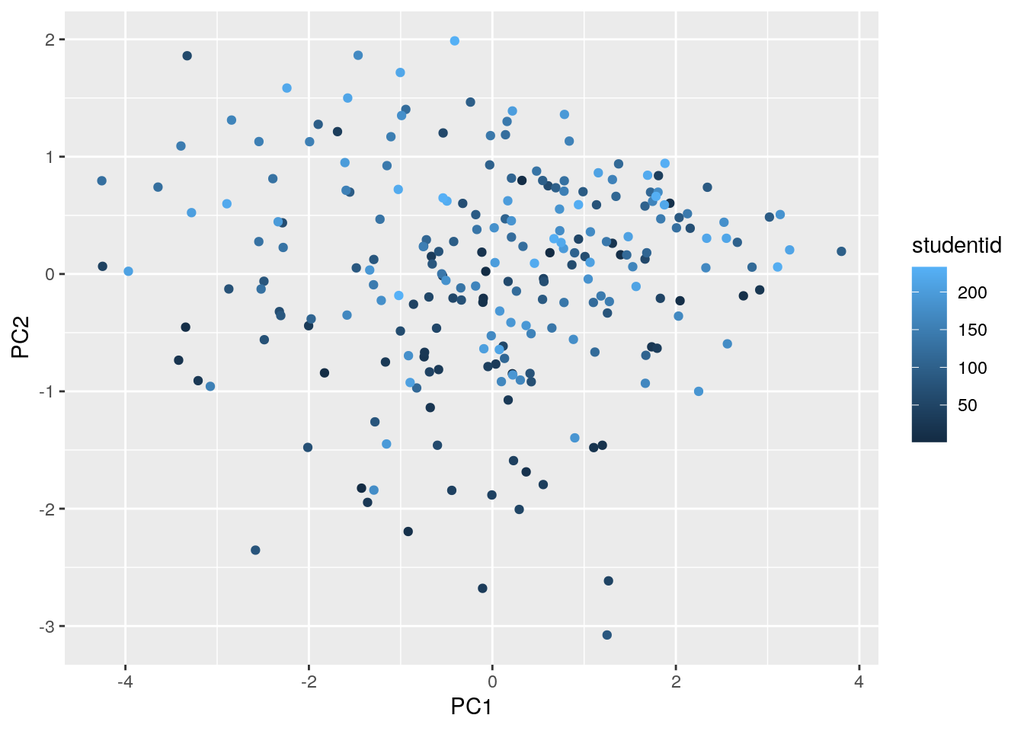

```r
grades %>% as.data.frame %>% select(studentid) %>% mutate(PC1 = pca1$scores[,
    1], PC2 = pca1$scores[, 2]) %>% ggplot(aes(PC1, PC2, color = studentid)) +
    geom_point()
```

Based on the rules of thumb, we can assume that the first two PCs will be retained. Although it should be noted that the second PC does not have an eigenvalue greater than 1 as seen by Kaiser’s rule. The first two PCs represent 82% of the total variance. The loadings for PC1 indicate that a higher scores on PC1 lead to higher scores in `exam1`, `exam2`, `exam3`, and `course_grade`. Higher scores on PC2 indicate higher scores in `exam1` and lower scores in `exam2` and `exam3`.